# 4. 中文分词

Natural Language Processing I

4. 中文分词

WU Xiaokun 吴晓堃

xkun.wu [at] gmail

2022/02/28

# N元语法

## 中文分词语料库：统计

- PKU：1998年《人民日报》
- MSR：微软亚洲研究
- 繁体：CITYU （香港城市大学）、AS （台湾中央研究院）

| 语料 | 字符 | 词目 | 词频 | 词长 |
| --- | --- | --- | --- | --- |
| **PKU** | 183万 | 6万 | 111万 | 1.6 |
| **MSR** | 405万 | 9万 | 237万 | 1.7 |
| **AS** | 837万 | 14万 | 545万 | 1.5 |
| **CITYU** | 240万 | 7万 | 146万 | 1.7 |

| 语料 | 字符 | 词目 | 词频 | 词长 | OOV |
| --- | --- | --- | --- | --- | --- |
| **PKU** | 17万 | 1万 | 10万 | 1.7 | 5.75% |
| **MSR** | 18万 | 1万 | 11万 | 1.7 | 2.65% |
| **AS** | 20万 | 2万 | 12万 | 1.6 | 4.33% |
| **CITYU** | 7万 | 1万 | 4万 | 1.7 | 7.40% |

## 中文分词语料库：比较

- 规模：AS > MSR > CITYU > PKU
- 从 OOV 看，难度：CITYU > PKU > AS > MSR
- 汉语平均词长：1.7
  - 长词都是低频词
- 汉语常用词汇量：10万级

| 语料 | 字符 | 词目 | 词频 | 词长 |
| --- | --- | --- | --- | --- |
| **PKU** | 183万 | 6万 | 111万 | 1.6 |
| **MSR** | 405万 | 9万 | 237万 | 1.7 |
| **AS** | 837万 | 14万 | 545万 | 1.5 |
| **CITYU** | 240万 | 7万 | 146万 | 1.7 |

| 语料 | 字符 | 词目 | 词频 | 词长 | OOV |
| --- | --- | --- | --- | --- | --- |
| **PKU** | 17万 | 1万 | 10万 | 1.7 | 5.75% |
| **MSR** | 18万 | 1万 | 11万 | 1.7 | 2.65% |
| **AS** | 20万 | 2万 | 12万 | 1.6 | 4.33% |
| **CITYU** | 7万 | 1万 | 4万 | 1.7 | 7.40% |

## 训练语法模型

训练：统计二元、一元语法词频

- **词频词典**：单词+词频[+词类]
- 计算概率分布：极大似然估计+平滑策略

词典可以看成模型的**存储形式**

## 词图

起点到终点每条路径代表一种分词

- 目标：找出**最合理**的路径
  - 以二元语法的概率作为距离：最长路径，或负对数的最短路径
- 例如：商品和服务

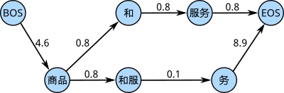

观察：决定路径的关键点在路径最后

- 全局算法，如动态规划

## Viterbi 算法

Markov 链构成的网状图上的最短路径

1. 前向：更新最小花费、前驱指针
2. 后向：回溯前驱指针

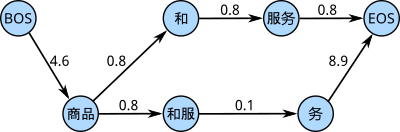

## 评测：N元语法

| 算法 | $P$ | $R$ | $F_1$ | $R_{OOV}$ | $R_{IV}$ |
| --- | --- | --- | --- | --- | --- |
| **最长匹配** | $91.80$ | $95.69$ | $93.71$ | $2.58$ | $98.22$ |
| **二元语法** | $\textbf{92.62}$ | $\textbf{96.85}$ | $\textbf{94.69}$ | $2.58$ | $\textbf{99.41}$ |

# 隐式Markov模型

## 隐式Markov模型

**隐式Markov模型 hidden Markov model (HMM)**

- 隐状态：Markov链，相互转化的**内因**
- 输出变量：由隐状态直接生成的**表象**

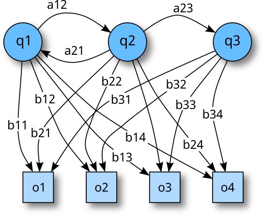

问题：依赖链长，计算复杂。

## HMM：一阶模型

一阶HMM的两个假设

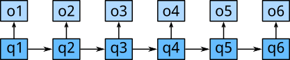

- 一阶Markov假设：状态概率只取决于**前一个**状态
  - 称为**状态转移概率**

$$P(q_i|q_1..q_{i-1}) = P(q_i|q_{i-1})$$

- 独立性假设：输出变量的概率只取决于**直接关联**的隐变量
  - 称为**观测似然**，或“**发射概率**”

$$P(o_i|q_1..q_{T},o_1..o_T) = P(o_i|q_{i})$$

## 评测：隐式Markov模型

| 算法 | $P$ | $R$ | $F_1$ | $R_{OOV}$ | $R_{IV}$ |
| --- | --- | --- | --- | --- | --- |
| **最长匹配** | $91.80$ | $95.69$ | $93.71$ | $2.58$ | $98.22$ |
| **二元语法** | $\textbf{92.62}$ | $\textbf{96.85}$ | $\textbf{94.69}$ | $2.58$ | $\textbf{99.41}$ |
| **一阶HMM** | $78.49$ | $80.38$ | $79.42$ | $41.11$ | $81.44$ |
| **二阶HMM** | $78.34$ | $80.01$ | $79.16$ | $\textbf{42.06}$ | $81.04$ |

# 感知机

## 感知机二分类模型

输入：$\mathbf{x}$；参数：$\mathbf{w}, b$；输出：

$$o = \sigma \left( \langle \mathbf{w}, \mathbf{x} \rangle + b\right),
\sigma(x) = \left\{ \begin{array}{ll}
1 & \text{if}\ x > 0 \\
-1 & \text{otherwise} \\
\end{array}\right.$$

二分类问题，激活函数通常输出：$\{-1,1\}$

- 回归：实数；softmax回归：概率
- 线性部分不变，**只改变激活函数**

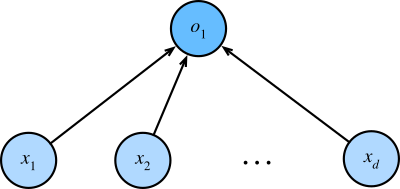

## 单隐藏层：小批量计算

$$\begin{aligned}
\textbf{H} &= \sigma(\textbf{X} \textbf{W}^h + \textbf{b}^h)\\
\textbf{O} &= \textbf{H} \textbf{W}^o + \textbf{b}^o\\
\end{aligned}$$

- $\textbf{X} \in \mathbb{R}^{B \times d}, \textbf{W}^h \in \mathbb{R}^{d \times l}, \textbf{b}^h \in \mathbb{R}^{1 \times l}$
- $\textbf{H} \in \mathbb{R}^{B \times l}, \textbf{W}^o \in \mathbb{R}^{l \times C}, \textbf{b}^o \in \mathbb{R}^{1 \times C}$

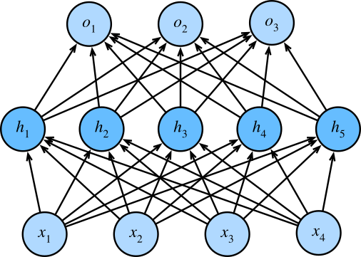

## 多隐藏层

$$\begin{aligned}
\textbf{h}_1 &= \sigma(\textbf{W}_1 \textbf{x} + \textbf{b}_1)\\
\textbf{h}_2 &= \sigma(\textbf{W}_2 \textbf{h}_1 + \textbf{b}_2)\\
\textbf{h}_3 &= \sigma(\textbf{W}_3 \textbf{h}_2 + \textbf{b}_3)\\
\textbf{o} &= \textbf{W}^o \textbf{h}_3 + \textbf{b}^o\\
\end{aligned}$$

超参数：取决于模型的**设计**

- 隐藏层数
- 每个隐藏层的大小

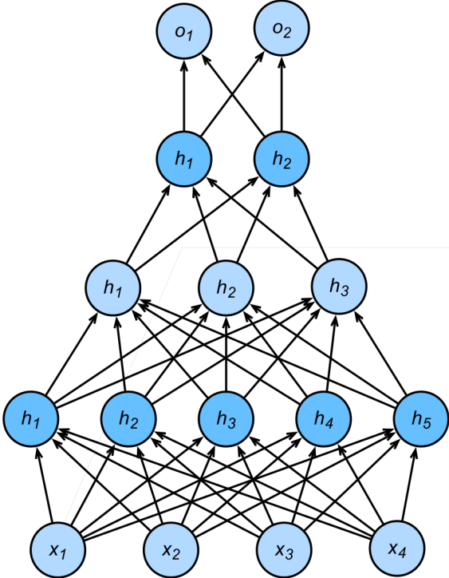

## 评测：感知机

| 算法 | $P$ | $R$ | $F_1$ | $R_{OOV}$ | $R_{IV}$ |
| --- | --- | --- | --- | --- | --- |
| **最长匹配** | $91.80$ | $95.69$ | $93.71$ | $2.58$ | $98.22$ |
| **二元语法** | $92.62$ | $\textbf{96.85}$ | $94.69$ | $2.58$ | $\textbf{99.41}$ |
| **一阶HMM** | $78.49$ | $80.38$ | $79.42$ | $41.11$ | $81.44$ |
| **二阶HMM** | $78.34$ | $80.01$ | $79.16$ | $42.06$ | $81.04$ |
| **平均感知机** | $\textbf{96.58}$ | $96.34$ | $\textbf{96.46}$ | $70.70$ | $97.04$ |
| **结构化感知机** | $96.07$ | $95.26$ | $95.66$ | $\textbf{72.68}$ | $95.88$ |

# 条件随机场

## 条件随机场 CRF

**条件随机场 conditional random field (CRF)**：直接计算后验，判别标签序列

$$\begin{aligned}
\hat{T} &= \argmax_{T \in \mathcal{T}} P(T|S)\\
\end{aligned}$$

- 对比 HMM：$\hat{T} = \argmax_{T} P(S|T) P(T)$

问题：每个时间步都计算整个标签序列$T$的概率

- 拆解成相关的**局部特征**，然后聚集并归一化

## 特征拆解

**全局特征$F_k(S, T)$**：每个都是整个输入序列$S$和输出序列$T$的特征

$$\begin{aligned}
P(T|S) &= \frac{1}{Z(S)} \exp \left( \sum_{k=1}^K w_k F_k(S, T) \right)\\
\end{aligned}$$

- $Z(S) = \sum_{T' \in \mathcal{T}} \exp \left( \sum_{k=1}^K w_k F_k(S, T') \right)$

简化计算：拆解成$T$每个位置上的**局部特征**之和

$$\begin{aligned}
F_k(S, T) &= \sum_{i=1}^n f_k(t_{i-1}, t_i, s_i, i)\\
\end{aligned}$$

- 称为**线性链式CRF**：特征计算只依赖于局部输出$t_{i-1}, t_i$

## 评测：条件随机场

| 算法 | $P$ | $R$ | $F_1$ | $R_{OOV}$ | $R_{IV}$ |
| --- | --- | --- | --- | --- | --- |
| **最长匹配** | $91.80$ | $95.69$ | $93.71$ | $2.58$ | $98.22$ |
| **二元语法** | $92.62$ | $\textbf{96.85}$ | $94.69$ | $2.58$ | $\textbf{99.41}$ |
| **一阶HMM** | $78.49$ | $80.38$ | $79.42$ | $41.11$ | $81.44$ |
| **二阶HMM** | $78.34$ | $80.01$ | $79.16$ | $42.06$ | $81.04$ |
| **平均感知机** | $96.58$ | $96.34$ | $96.46$ | $70.70$ | $97.04$ |
| **结构化感知机** | $96.07$ | $95.26$ | $95.66$ | $\textbf{72.68}$ | $95.88$ |
| **条件随机场** | $\textbf{96.86}$ | $96.64$ | $\textbf{96.75}$ | $71.54$ | $97.33$ |

# 词类标注

## 词类、词类标注

词类：也称词性，即单词的语法分类

- 名词、动词、形容词等

词类标注：给每个词一个词类标签

- 一词多类问题：如“她希望成为全村人的希望。”
- OOV问题：同类词义推断，如“头上戴着束发嵌宝紫金冠”

中文词类：属于现代研究，深受西方影响

- 标注规范存在分歧，且受版权控制

## 现代汉语词类表

| 类别 | 细分 | 举例 |  | 类别 | 细分 | 举例 |
| --- | --- | --- | --- | --- | --- | --- |
| 名词 | 具体、抽象 | 人、意 |  | 量词 | 名量 | 把 |
|  | 方位 | 东 |  |  | 动量 | 次 |
| 代词 | 人称、指示、疑问 | 我、这、谁 |  | 副词 | 程度、范围、否定 | 很、都、未 |
| 动词 | 不及物、及物 | 醒、看 |  | 介词 | 时间、原因、比较 | 自、因、比 |
|  | 可能、必要、愿意 | 能、应、愿 |  | 连词 | 联合、偏正 | 和、但 |
|  | 趋向 | 来 |  | 助词 | 结构、时态、语气 | 的、过、呢 |
| 形容词 | 性质、状态 | 大、烫 |  | 叹词 | 喜悦、愤怒、呼唤 | 哈、哼、喂 |
| 数词 | 基数、倍数、概述 | 百、倍、几 |  | 象声词 |  | 哗 |

## 标注集

《人民日报》语料库与PKU标注集

- 1998年1月份的词性标注语料库

国家语委语料库

- 2006年国标：《信息处理用现代汉语词类标注集规范》

## 实验：词类标注

# 命名实体识别

## 命名实体、命名实体识别

命名实体：描述实体的词汇

- 人名 PER、组织 ORG、地点 LOC、地域 GPE

命名实体识别：专有名词的分词

- 起止范围 + 标签类型
  - 语料库颗粒较大时：分类 + 词类
  - 复合词已拆分时：规则、统计

## 基于规则的NER

例如：音译用字较为固定、歧义小，而名称较长

1. 粗分：确定备选词是否音译字序列
2. 从备选词向右扫描，合并音译用字

```
列宁/nh 格勒/ns 被包围，但并未被攻占。
```

音译名称专用词典

- 误命中问题：谨慎触发规则1

## 实验：命名实体识别